<a id = 000></a>

# Boston Crime Data Anlysis

### Team: Zelta

### Member: Yuntao Ma

The data was found in Kaggle data set. The origin of the data was from [Boston Crime Data](https://www.kaggle.com/ankkur13/boston-crime-data). The author of the data was [Ankur Jain](https://www.kaggle.com/ankkur13)

### Index:

Modual

Class and Function

Data Processing

Analysis

Reflection

Something Fun

### Abstract:

The goal of this project is to investigate the crime pattern from 2015 to 2018 in Boston. Type of crimes, time of crimes, the location of crimes, and their relationship was studied. The data was from Kaggle Boston Crime Dataset. The data was based on the police report from 2015 to 2018. The crime time pattern in a day was found. Crime location was visualized on a map, and some particular location in the dense urban area was indicated as "No-Crime Zone". It was indicated based on our own evaluating system that the Boston is becoming safer from 2015 to 2018.

<a id = 100></a>

# Modual:

back to the top

For this project, following modual was used:

*csv*: process csv file

*matplotlib.pyplot*: ploting graph, read and plot image was learn in previouse experiences working with this library

```python
import csv
import matplotlib.pyplot as plt

# fig_num make sure the figure is not open twice
# fig_num is a list in order to pass by reference everywhere
fig_num = [1]
```

<a id = 101></a>

# Class and Functions:

back to the top

### Data Store Method:

**Class: crime_case:**

*constructor*: store the coresponding data from each crime case into: 0. id (id of the crime); 1. type (type of the crime); 2. district_code (distrct code of where crime happened); 3. date (a list of [year, month, day of the week]); 4. hour (the hour of the day when crime happened); 5. location (the corrinate of where the crime happened)

*get*: A function give easy access to the data store in the calss by using index to indicate different data:

| input | return |
| --- | --- |
| 0 | self.id |
| 1 | self.type |
| 2 | self.district_code |
| 3 | self.date |
| 4 | self.hour |
| 5 | self.location |

out of range input will return None.

```python
class crime_case:
    def __init__(self, data_list):
        self.id = data_list[0]
        self.type = data_list[1]
        self.district_code = data_list[2]
        self.date = [int(data_list[3]), int(data_list[4]), data_list[5]]
        self.hour = int(data_list[6])
        self.location = data_list[7]

    def get(self, index):
        if index == 0:
            return self.id
        elif index == 1:
            return self.type
        elif index == 2:
            return self.district_code
        elif index == 3:
            return self.date
        elif index == 4:
            return self.hour
        elif index == 5:
            return self.location
        else:
            return None
```

### Function:

**column_rank**

Rank how many unique elements is in the type of data, it return a dictionary take the element as key and number of the element in the column and sorted from the greatest to the samllest

*Input:*

Index: the index of the column in the class (see .get method description)

obj_list: list of crime_case object

*Output:*

dict: a list of sorted tuple

```python
def column_rank (index, obj_list):
    dict = {}

    for obj in obj_list:
        if obj.get(index) in dict:
            dict[obj.get(index)] += 1
        else:
            dict[obj.get(index)] = 1

    return sorted(dict.items(), key = lambda x: x[1], reverse = True)
```

**crime_on_map**

Put valid crime location on the map using scatter plot and a carefully screen shot of the google map as background. The size of the dot on the map is depend on the number of cases for better visibility.

*Input:*

fig_num: figure number to avoid plotting in the same figure

crime_type: optional input, type of crime you want to plot on the map, default to all type of crime

year: optional input, year of crime you want to plot on the map, default to all 4 years

hour: optional input, time of the day when crime happened, default to all days

*Output:*

None: Output a graph

```python
def crime_on_map (fig_num, crime_type = 'all', year = 'all', hour = 'all'):
    ys = []
    xs = []

    for obj in crime_cases:
        # get cordinate
        cor = obj.get(5).strip('()').split(', ')
        y, x = float(cor[0]), float(cor[1])

        # ignore any invalid cordinate
        if y < 40:
            continue

        # ignore any invalid type of crime
        if not crime_type == 'all' and not crime_type == obj.get(1):
            continue
        # ignore any invalid year
        if not year == 'all' and not year == obj.get(3)[0]:
            continue
        #ignore any invalid hour
        if not hour == 'all' and not hour == obj.get(4):
            continue

        # create a list of corrdinate
        ys.append(y)
        xs.append(x)

    # if there is nothing in the cordinate, it means crime type was invalid
    if len(ys) == 0:
        print('None Crime Found Base on Input')
        return None

    # create figure, and put piciture in the backgroud
    plt.figure(fig_num[0],  dpi= 150)
    fig_num[0] += 1
    img = plt.imread('boston_map.png')
    plt.imshow(img, extent=[-71.20, -70.95, 42.23, 42.41])

    # Configure size of dot based on how many corrdinate to help better viewing
    size = 1/((len(ys)/40))

    # plot all the locations
    plt.title('{} Cases of {} Type of Crimes'.format(len(xs), crime_type))
    plt.text(-70.94, 42.38, 'Type: {}\nYear: {}\nHour: {}'.format(crime_type, year, hour))
    plt.scatter(xs,ys, s=size, c='r')
    plt.yticks([42.23, 42.41])
    plt.xticks([-71.20,-70.95])
    plt.show()
```

**score**:

score the district based on the pre-assign weight by evaluating each type of crime. Each type of crime is assigned a score range from 1-10 based on seriousness, where 1 is the least serious, and 10 is the most serious. **WARN: The assigned weight is purely based on my own perception, subjective bias could be added to analysis** The score is normalized based on the number of crime in the district.

*input:*

obj_list: list of crime_case object

*output:*

score: a normalized score in scale 1-10 indicate how danger the list is (the lower is safer)

```python
def score (obj_list):
    # weight dictionary bsed on personal opnion
    weight = {'Motor Vehicle Accident Response': 2, 'Larceny': 4, 'Medical Assistance': 1, 'Investigate Person': 2,
              'Other': 1, 'Drug Violation': 5, 'Simple Assault': 5, 'Vandalism': 3, 'Verbal Disputes': 3, 'Towed': 1,
              'Investigate Property': 3, 'Larceny From Motor Vehicle': 4, 'Property Lost': 6, 'Warrant Arrests': 8,
              'Aggravated Assault': 8, 'Violations': 5, 'Fraud': 3, 'Residential Burglary': 7, 'Missing Person Located': 1,
              'Auto Theft': 7, 'Robbery': 9, 'Harassment': 9, 'Property Found': 1, 'Missing Person Reported': 3,
              'Confidence Games': 1, 'Police Service Incidents': 1, 'Disorderly Conduct': 3, 'Fire Related Reports': 4,
              'Firearm Violations': 8, 'License Violation': 3, 'Restraining Order Violations': 5,
              'Recovered Stolen Property': 1, 'Counterfeiting': 1, 'Commercial Burglary': 8, 'Liquor Violation': 2,
              'Auto Theft Recovery': 1, 'Ballistics': 7, 'Landlord/Tenant Disputes': 2, 'Search Warrants': 5,
              'Assembly or Gathering Violations': 3, 'Property Related Damage': 5, 'Firearm Discovery': 5,
              'Operating Under the Influence': 4, 'License Plate Related Incidents': 2, 'Offenses Against Child / Family': 9,
              'Other Burglary': 7, 'Evading Fare': 1, 'Embezzlement': 1, 'Service': 1, 'Prisoner Related Incidents': 5,
              'Harbor Related Incidents': 1, 'Prostitution': 3, 'Homicide': 10, 'Criminal Harassment': 9, 'Arson': 10,
              'HOME INVASION': 10, 'Bomb Hoax': 10, 'Aircraft': 1, 'Phone Call Complaints': 1, 'Explosives': 10,
              'Manslaughter': 10, 'Gambling': 2, 'HUMAN TRAFFICKING': 10, 'INVESTIGATE PERSON': 2, 'Biological Threat': 8,
              'HUMAN TRAFFICKING - INVOLUNTARY SERVITUDE': 10, 'Burglary - No Property Taken': 5}

    # call column rank function to get type of crime in the list and number of each type of crime
    crime_types = column_rank(1, obj_list)

    # calculate the weight score
    total_score = 0
    for types, number in crime_types:
        total_score += weight[types] * number

    # normalization
    score = total_score/len(obj_list)

    return score
```

<a id = 102></a>

# Data Processing:

back to the top

**imoport, clean, and store the data**

Processing data using csv modual, isolate header and data;

Store the data in a list of crime_case object by construct a list of useful data and pass it to the constructor of the crime_case class

```python
# open file and get data using csv modual
with open('crime.csv') as f:
    raw = csv.reader(f)
    header = next(raw)
    data = list(raw)

# extract useful data and create class
crime_cases = []
for alist in data:
    useful_list = [alist[0], alist[2], alist[4], alist[8], alist[9], alist[10], alist[11], alist[-1]]

    crime_cases.append(crime_case(useful_list))
```

**Store data by district**

Create a dictionary take the police department area as key and the corresponding list of object as value

Example: police_area_dict = {'Downtown': [ \< crime_caseobj1 >, \< crime_case obj2 >, ...].....}

A dictionaryt taken the district code as key, and corresponding area as the value: (data from [Boston Police](https://www.boston.gov/departments/police))

```python
police_area = {'A1':'Downtown', 'A15':'Charlestown', 'A7':'East Boston',
               'B2':'Roxbury', 'B3':'Mattapan', 'C6':'South Boston',
               'C11':'Dorchester', 'D4':'South End', 'D14': 'Brighton',
               'E5':'West Roxbury', 'E13':'Jamaica Plain', 'E18': 'Hyde Park'}
```

```python
police_area_dict = {}

# create the dictionary key
for key, value in police_area.items():
    if value not in police_area_dict:
        police_area_dict[value] = []

for obj in crime_cases:
    for key in police_area:
        if obj.get(2) == key:
            police_area_dict[police_area[key]].append(obj)
```

**All Type of Crimes:**

Display all different type of crimes (You could use this list for some function input):

```python
type_of_crime = column_rank(1, crime_cases)

print([key for key,value in type_of_crime])
```

[output not shown]

<a id = 103></a>

# Analysis:

back to the top

### 1. Top 10 Type of crimes:

```python
crime_type = column_rank(1, crime_cases)

# print the result
counter = 1
print('Top 10 Type of crimes:')
for key, value in crime_type:
    print('{:>2}: {:<35}{:>5} cases'.format(counter, key, value))
    counter += 1

    if counter == 11:
        break
```

```
Top 10 Type of crimes:
 1: Motor Vehicle Accident Response    38134 cases
 2: Larceny                            26670 cases
 3: Medical Assistance                 24226 cases
 4: Investigate Person                 19176 cases
 5: Other                              18612 cases
 6: Drug Violation                     17037 cases
 7: Simple Assault                     16263 cases
 8: Vandalism                          15810 cases
 9: Verbal Disputes                    13478 cases
10: Towed                              11632 cases
```

**Discussion:**

The analysis using the column rank function to get the number of the case for each type of crimes. It seems most of the time the top crimes are minor offenses, such as vehicle accident response, verbal dispute and so on. The data consist of 327820 cases, the top 10 list has 201038 cases, which was about 61.3% of all criminal cases.

### 2. Number of Crime during each hour:

```
Number of Crime during each hour
0:00 - 1:00:     15534 cases
1:00 - 2:00:      9502 cases
2:00 - 3:00:      7895 cases
3:00 - 4:00:      4710 cases
4:00 - 5:00:      3505 cases
5:00 - 6:00:      3409 cases
6:00 - 7:00:      5174 cases
7:00 - 8:00:      9095 cases
8:00 - 9:00:     13441 cases
9:00 - 10:00:    15157 cases
10:00 - 11:00:   16836 cases
11:00 - 12:00:   16904 cases
12:00 - 13:00:   19198 cases
13:00 - 14:00:   17292 cases
14:00 - 15:00:   17659 cases
15:00 - 16:00:   16963 cases
16:00 - 17:00:   20373 cases
17:00 - 18:00:   21350 cases
18:00 - 19:00:   20908 cases
19:00 - 20:00:   18055 cases
20:00 - 21:00:   16300 cases
21:00 - 22:00:   14460 cases
22:00 - 23:00:   13244 cases
23:00 - 24:00:   10856 cases
```

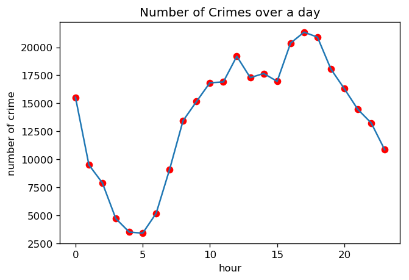

```python
crime_each_hour = column_rank(4, crime_cases)

# re-sort the list base on the time of the day
crime_each_hour = sorted(crime_each_hour, key = lambda x: x[0])
print('Number of Crime during each hour')

# print out hte result
hours, numbers = [], []
for hour, number in crime_each_hour:
    print('{0:<15} {1:>6} cases'.format('{0}:00 - {1}:00:'.format(hour, hour+1), number))
    hours.append(hour)
    numbers.append(number)

# plot the data
plt.figure(fig_num[0], dpi= 120)
fig_num[0] += 1
plt.plot(hours, numbers,'ro', hours, numbers)
plt.title('Number of Crimes over a day')
plt.xlabel('hour')
plt.ylabel('number of crime')
plt.show()
```

**Discussion:**

I have expected that more crimes happened late at night, however, it was the opposite. The trend follows how active people are during the day. The crimes die down around 7 o'clock at night and reach a minimum around 5 a.m. in the morning. Then ramp up again and reach a consistent number around 10 in the morning and increase again around 3 in the afternoon and reach the peak at 5 in the afternoon.

According to the Analysis.1, this trend could be related to the number of this minor offense usually happen during the day. However, this data was collected based on the police report, it could also be there are fewer people to report the crime to the police late at night.

### 3. Number of Crime in Each District:

```
District From Most crimes to Least:
Roxbury           51288 cases
Dorchester        43817 cases
South End         43338 cases
Downtown          36735 cases
Mattapan          36400 cases
South Boston      24190 cases
Brighton          20632 cases
Jamaica Plain     17981 cases
Hyde Park         17825 cases
East Boston       13634 cases
West Roxbury      13543 cases
Charlestown        6663 cases
```

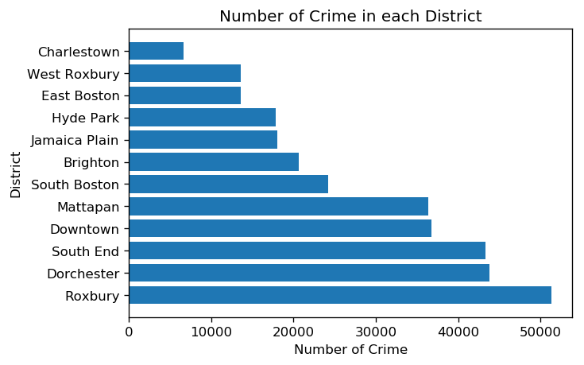

[figure not shown]

```python
districts = []

# put district and number of cases in to a list of list
for key, value in police_area_dict.items():
    districts.append([key,len(value)])

# sorted base on the number of cases from high to low
districts = sorted(districts, key = lambda x: x[1], reverse = True)

x = []
y = []

# output result
print('District From Most crimes to Least:')
for item in districts:
    print('{:<13}{:>10} cases'.format(item[0], item[1]))
    y.append(item[1])
    x.append(item[0])

# graphic output
plt.figure(fig_num[0], dpi= 120)
fig_num[0] += 1

plt.barh(x,y)
plt.title('Number of Crime in each District')
plt.ylabel('District')
plt.xlabel('Number of Crime')
plt.show()

crime_on_map(fig_num)
```

**Discussion:**

From the map, the downtown area has the most number of the crime. The sub-urban area tends to have fewer crimes in number. Also from the map, the more concentrated crime area has a darker color, and it seems a lot of the color follow a major high way or major roads. It could indicate that a lot of crimes was traffic related, considering motor vehicle accident was the top 1 crime type.

Another interesting finding was that, in the downtown area, there is some "empty spot". One empty spot was in the middle of the map, around the South Boston area. The south station was located in the empty spot. Considering, the south station is relatively big and constrained to outside. No one could access it. It makes sense that there is barely any crimes there. Another small "empty spot" is a bit west to the south station alone the Huntington Ave. The spot is Northeastern University. The Northeastern is such a safe spot!

### 4. Top3 type of crimes in each district:

```python
print('Top 3 type of crimes in each district:')

for key, value in police_area_dict.items():
    district_type = column_rank(1, value)
    print(key+':')
    print('Top 1: {:<35} {:>4} cases\nTop 2: {:<35} {:>4} cases\nTop 3: {:<35} {:>4} cases\n'.
          format(district_type[0][0], district_type[0][1],
                 district_type[1][0], district_type[1][1],
                 district_type[2][0], district_type[2][1]))
```

```
Top 3 type of crimes in each district:
Downtown:
Top 1: Larceny                             4849 cases
Top 2: Motor Vehicle Accident Response     2936 cases
Top 3: Simple Assault                      2401 cases

Charlestown:
Top 1: Motor Vehicle Accident Response      984 cases
Top 2: Larceny                              517 cases
Top 3: Medical Assistance                   494 cases

East Boston:
Top 1: Motor Vehicle Accident Response     1545 cases
Top 2: Medical Assistance                  1314 cases
Top 3: Drug Violation                       880 cases

Roxbury:
Top 1: Motor Vehicle Accident Response     6590 cases
Top 2: Medical Assistance                  3446 cases
Top 3: Other                               3401 cases

Mattapan:
Top 1: Motor Vehicle Accident Response     3934 cases
Top 2: Verbal Disputes                     3047 cases
Top 3: Investigate Person                  2535 cases

South Boston:
Top 1: Motor Vehicle Accident Response     2793 cases
Top 2: Larceny                             1971 cases
Top 3: Medical Assistance                  1956 cases

Dorchester:
Top 1: Motor Vehicle Accident Response     5461 cases
Top 2: Medical Assistance                  3388 cases
Top 3: Investigate Person                  2744 cases

South End:
Top 1: Larceny                             7554 cases
Top 2: Motor Vehicle Accident Response     3980 cases
Top 3: Medical Assistance                  2442 cases

Brighton:
Top 1: Motor Vehicle Accident Response     2928 cases
Top 2: Medical Assistance                  1677 cases
Top 3: Larceny                             1671 cases

West Roxbury:
Top 1: Motor Vehicle Accident Response     1852 cases
Top 2: Medical Assistance                  1549 cases
Top 3: Investigate Person                  1062 cases

Jamaica Plain:
Top 1: Motor Vehicle Accident Response     2232 cases
Top 2: Medical Assistance                  1468 cases
Top 3: Larceny                             1224 cases

Hyde Park:
Top 1: Motor Vehicle Accident Response     2437 cases
Top 2: Medical Assistance                  1731 cases
Top 3: Investigate Person                  1221 cases
```

**Discussion:**

It is interesting that the top 1 crime type in the most district are Motor Vehicle Accident Response. However, in Downtown and South End, larceny is the top 1 crimes type and higher than the second crime type by a lot. It could interperate that both the South End and Downtown are the dense urban living area, where larceny is more common due to dense population. It could be interesting to look for other datasets to understand the population composition, infrastructure, and economics of the area.

It is also interesting that, even though the Roxbury has the highest prime number, the top 3 type of crimes were relatively minor.

### 5. Crime time trend for each district:

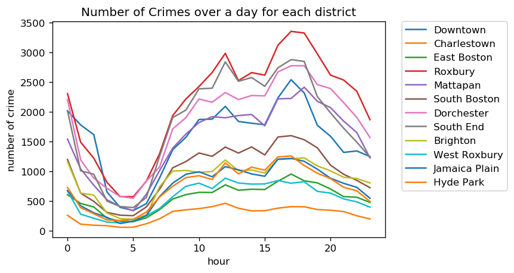

```python
# create figure for plot
plt.figure(fig_num[0], dpi= 120)
fig_num[0] += 1

for key, value in police_area_dict.items():
    district_hour = column_rank(4, value)
    # sorted by hour from 0 - 24
    district_hour = sorted(district_hour, key = lambda x: x[0])

    # extract hour and number of crime data
    hours, numbers = [], []
    for hour, number in district_hour:
        hours.append(hour)
        numbers.append(number)


    plt.plot(hours, numbers, label = key)



plt.title('Number of Crimes over a day for each district')
plt.xlabel('hour')
plt.ylabel('number of crime')
# make the legend out side of plot
plt.legend(bbox_to_anchor=(1.05, 1), loc='upper left', borderaxespad=0.)
plt.show()
```

**Discussion:**

The time trends of the number of crime consist of the overall time trend. The district has more data sample reflect the overall time trend more, while the district has less data sample has a relatively flat time trend. However, the overall trend is a good reflection of the all crime time trend.

### 6. Safty score of each district:

```python
district_score = []

# score all district by calling score function
for key, value in police_area_dict.items():
    district_score.append([key, score(value)])

# sorted the list by lowest score to highest score
district_score = sorted(district_score, key = lambda x: x[1])

# output
print('Score of each district based on weighted crime type and normalization:(Lower is Better)')
count = 1
for item in district_score:
    print('Rank {:<2}: {:<15} {:>10}{:<3.2f}'.format(count, item[0], 'Score:', item[1]))
    count += 1
```

```
Score of each district based on weighted crime type and normalization:(Lower is Better)
Rank 1 : West Roxbury        Score:3.13
Rank 2 : Brighton            Score:3.25
Rank 3 : Charlestown         Score:3.27
Rank 4 : Hyde Park           Score:3.28
Rank 5 : East Boston         Score:3.42
Rank 6 : South Boston        Score:3.42
Rank 7 : Jamaica Plain       Score:3.44
Rank 8 : Dorchester          Score:3.46
Rank 9 : Mattapan            Score:3.49
Rank 10: Roxbury             Score:3.57
Rank 11: South End           Score:3.60
Rank 12: Downtown            Score:3.70
```

**Discussion:**

All district score within 3-4 range, which indicate Boston is an overall safe city based on the scoring system.

The 5 least safe districts based on the scoring system are the same as the top 5 most crime case district but in a different order. Since the data was normalized, the number of crime was not factored into the score. In this way, this 5 district not only have more crimes, but also more dangerous crime.

The top 3 safest districts are all in out-skirt of the Boston. The rank of this list somewhat reflects the personal experience when traveling around the Boston.

### 7. Safty score of each district over time:

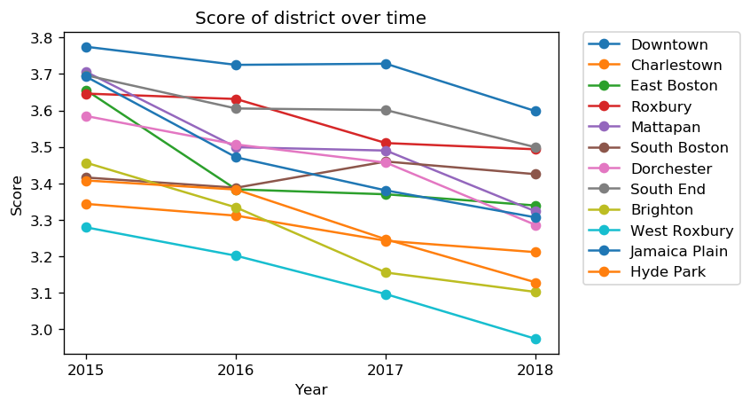

```
Safty score of each district by year:
West Roxbury:
2015 score: 3.28;  2016 score: 3.20;  2017 score: 3.10;  2018 score: 2.97;
Change from 2015 to 2018: -0.31

Brighton:
2015 score: 3.46;  2016 score: 3.33;  2017 score: 3.16;  2018 score: 3.10;
Change from 2015 to 2018: -0.35

Charlestown:
2015 score: 3.34;  2016 score: 3.31;  2017 score: 3.24;  2018 score: 3.21;
Change from 2015 to 2018: -0.13

Hyde Park:
2015 score: 3.41;  2016 score: 3.38;  2017 score: 3.25;  2018 score: 3.13;
Change from 2015 to 2018: -0.28

East Boston:
2015 score: 3.66;  2016 score: 3.38;  2017 score: 3.37;  2018 score: 3.34;
Change from 2015 to 2018: -0.32

South Boston:
2015 score: 3.42;  2016 score: 3.39;  2017 score: 3.46;  2018 score: 3.43;
Change from 2015 to 2018: 0.01

Jamaica Plain:
2015 score: 3.69;  2016 score: 3.47;  2017 score: 3.38;  2018 score: 3.31;
Change from 2015 to 2018: -0.39

Dorchester:
2015 score: 3.58;  2016 score: 3.51;  2017 score: 3.46;  2018 score: 3.29;
Change from 2015 to 2018: -0.30

Mattapan:
2015 score: 3.71;  2016 score: 3.50;  2017 score: 3.49;  2018 score: 3.32;
Change from 2015 to 2018: -0.38

Roxbury:
2015 score: 3.65;  2016 score: 3.63;  2017 score: 3.51;  2018 score: 3.49;
Change from 2015 to 2018: -0.15

South End:
2015 score: 3.70;  2016 score: 3.61;  2017 score: 3.60;  2018 score: 3.50;
Change from 2015 to 2018: -0.20

Downtown:
2015 score: 3.77;  2016 score: 3.73;  2017 score: 3.73;  2018 score: 3.60;
Change from 2015 to 2018: -0.18
```

```python
case_by_year = {}

# extract the object in each district and create a dictionary take year as key and the list of crime_case object
# in that year and distrct
for key, value in police_area_dict.items():
    case_by_year[key] = {}

    for obj in value:
        if obj.get(3)[0] in case_by_year[key]:
            case_by_year[key][obj.get(3)[0]].append(obj)
        else:
            case_by_year[key][obj.get(3)[0]] = []
            case_by_year[key][obj.get(3)[0]].append(obj)

# get score by year
year_score = {}
for key, value in case_by_year.items():
    year_score [key] = []
    for k,v in value.items():
        year_score [key].append([k, score(v)])
    # sort the list to make it start at 2015
    year_score[key] = sorted(year_score[key], key = lambda x: x[0])

# create figure for plot
plt.figure(fig_num[0], dpi= 120)
fig_num[0] += 1

# graph output
x = [2015, 2016, 2017, 2018]
for key, value in year_score.items():
    y = []
    for item in value:
        y.append(item[1])

    plt.plot(x, y, marker = 'o', label = key )

plt.title('Score of district over time')
plt.xlabel('Year')
plt.ylabel('Score')
plt.legend(bbox_to_anchor=(1.05, 1), loc='upper left', borderaxespad=0.)
plt.xticks(x)
plt.show()

# printwee out result
# using the previouse anlysis rank as order of district
print('Safty score of each district by year:')
for item in district_score:
    print('{}:'.format(item[0]))
    print('{} score: {:.2f};  {} score: {:.2f};  {} score: {:.2f};  {} score: {:.2f};'
          .format(year_score[item[0]][0][0], year_score[item[0]][0][1],
                  year_score[item[0]][1][0], year_score[item[0]][1][1],
                  year_score[item[0]][2][0], year_score[item[0]][2][1],
                  year_score[item[0]][3][0], year_score[item[0]][3][1]))
    print('Change from 2015 to 2018: {:.2f}\n'.format(year_score[item[0]][3][1] - year_score[item[0]][0][1]))
```

**Discussion:**

Overall, most of the district score has a downward trend over time, which indicate most districts were becoming safer over the time. Also, overall raking did not have significant change over time.

**The crime on the map from 2015 to 2018:**

[figure not shown]

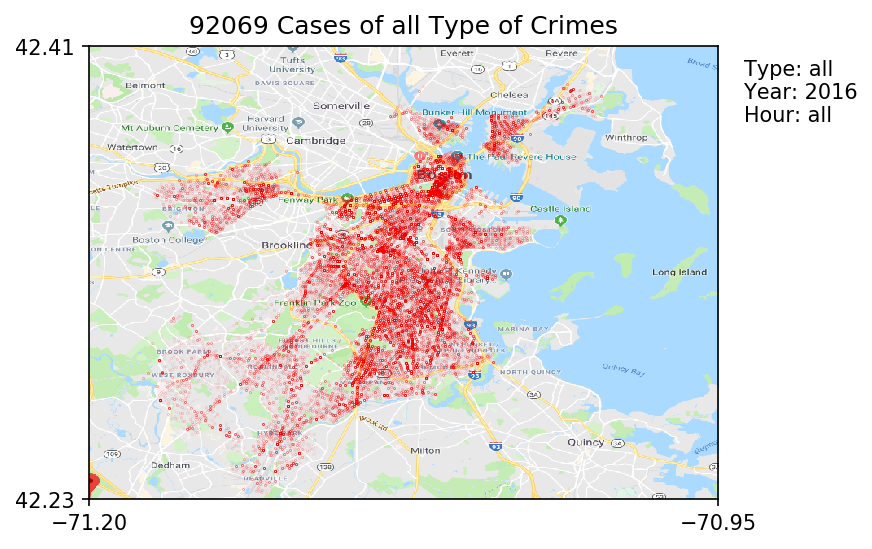

[figure not shown]

[figure not shown]

```python
crime_on_map(fig_num, year=2015)
crime_on_map(fig_num, year=2016)
crime_on_map(fig_num, year=2017)
crime_on_map(fig_num, year=2018)
```

## Conclusion

From the data analysis, we can conclude that Boston is a safe city. Most of the crimes happened in Boston were consisted of minor offenses. The serious crimes, such as murder and robbery were only occupied less than 1% of all criminal cases. The time of the crime was based on human activity throughout the day. When people are more active, such as afternoon, more crimes happened. At night, when people are sleeping, fewer crimes happened. The urban area was considered less safe than the suburban area. It could be related to a more concentrated population. Population and economics data should be also considered for further analysis. The trend line of score over years indicates that the most Boston district is becoming safer and safer. We see the score improved across the board for 11 out of 12 districts from 2015 to 2018.

<a id = 104></a>

# Reflection:

back to the top

The police department, private security company, and the general population could benefit from the conclusion of the analysis. The police department could use this analysis to arrange the personal to the important area at the right time of the day. Private security company could use this data to assist the customer better. They could deploy more camera in the area where home invasion or robbery happen more frequently. It is also a good information for the general public. People could be more careful when going to a particular area. It would be nice to provide this information for new-comers from a different city, so they would know which area they should avoid. The data consists about 320 thousand cases over 4 years. The sample space was large enough to reasonably draw some conclusion.

One potential downfall of this project was that the data was solely based on the police report. There might be more dangerous crime happened and not reported that does not add to the consideration. It could mislead the public that some area is less safe than it appears in the analysis. The analysis does not imply any causation between district and type or number of crimes, only the relationship.

The scoring system used in the analysis was purely subjective based on personal perspective and bias. It could subject to cultural influenced, personal experience, and political opinions. Other could weight different crime differently, which could affect the score of the district. More survey could be made to gather data about how people would weight different kind of crime, which could make the weighting represent a broader population.

The outcome of this analysis could also be linked with other data such as economics data or population data to further investigate the overall social behavior of Boston.

<a id = 105></a>

# Something Fun:

back to the top

Create your own crime map with *crime_on_map* function

**crime_type option:** **1.**'Motor Vehicle Accident Response', **2.**'Larceny', **3.**'Medical Assistance', **4.**'Investigate Person', **5.**'Other', **6.**'Drug Violation', **7.**'Simple Assault', **8.**'Vandalism', **9.**'Verbal Disputes', **10.**'Towed', **11.**'Investigate Property', **12.**'Larceny From Motor Vehicle', **13.**'Property Lost', **14.**'Warrant Arrests', **15.**'Aggravated Assault', **16.**'Violations', **17.**'Fraud', **18.**'Residential Burglary', **19.**'Missing Person Located', **20.**'Auto Theft', **21.**'Robbery', **22.**'Harassment', **23.**'Property Found', **24.**'Missing Person Reported', **25.**'Confidence Games', **26.**'Police Service Incidents', **27.**'Disorderly Conduct', **28.**'Fire Related Reports', **29.**'Firearm Violations', **30.**'License Violation', **31.**'Restraining Order Violations', **32.**'Recovered Stolen Property', **33.**'Counterfeiting', **34.**'Commercial Burglary', **35.**'Liquor Violation', **36.**'Auto Theft Recovery', **37.**'Ballistics', **38.**'Landlord/Tenant Disputes', **39.**'Search Warrants', **40.**'Assembly or Gathering Violations', **41.**'Property Related Damage', **42.**'Firearm Discovery', **43.**'Operating Under the Influence', **44.**'License Plate Related Incidents', **45.**'Offenses Against Child / Family', **46.**'Other Burglary', **47.**'Evading Fare', **48.**'Embezzlement', **49.**'Service', **50.**'Prisoner Related Incidents', **51.**'Harbor Related Incidents', **52.**'Prostitution', **53.**'Homicide', **54.**'Criminal Harassment', **55.**'Arson', **56.**'HOME INVASION', **57.**'Bomb Hoax', **58.**'Aircraft', **59.**'Phone Call Complaints', **60.**'Explosives', **61.**'Manslaughter', **62.**'Gambling', **63.**'HUMAN TRAFFICKING', **64.**'INVESTIGATE PERSON', **65.**'Biological Threat', **66.**'HUMAN TRAFFICKING - INVOLUNTARY SERVITUDE', **67.**'Burglary - No Property Taken'

**year option:** **1.** 2015, **2.** 2016, **3.** 2017, **4.** 2018

[figure not shown]

```python
crime_on_map(fig_num, crime_type='Motor Vehicle Accident Response', year = 2018, hour = 17)
```